# Post-process data in a trajectory

Stefan Widgren

After a model is created, a simulation is started with a call to the `run()` function with the model as the first argument. The function returns a modified model object with a single stochastic solution trajectory attached to it. Trajectory data contains the state of each compartment, recorded at every time-point in `tspan`. This document introduces you to functionality in `SimInf` to post-process and explore that trajectory data.

## Extract trajectory data with `trajectory()`

Most modelling and simulation studies require custom data analysis once the simulation data has been generated. To support this, SimInf provides the `trajectory()` method to obtain a `data.frame` with the number of individuals in each compartment at the time points specified in `tspan`.

Let’s simulate 10 days of data from an SIR model with 6 nodes. For reproducibility, we first call the `set.seed()` function and specify the number of threads to use for the simulation.

```r
library(SimInf)

set.seed(123)
set_num_threads(1)

u0 <- data.frame(S = c(100, 101, 102, 103, 104, 105),
                 I = c(1, 2, 3, 4, 5, 6),
                 R = c(0, 0, 0, 0, 0, 0))

model  <- SIR(u0 = u0,
              tspan = 1:10,
              beta = 0.16,
              gamma = 0.077)

result <- run(model)
```

Extract the number of individuals in each compartment at the time-points in `tspan`.

```r
trajectory(result)
```

```
##    node time   S  I R
## 1     1    1 100  1 0
## 2     2    1 101  2 0
## 3     3    1 102  3 0
## 4     4    1 102  5 0
## 5     5    1 103  6 0
## 6     6    1 105  6 0
## 7     1    2 100  1 0
## 8     2    2 101  2 0
## 9     3    2 101  4 0
## 10    4    2 101  5 1
## 11    5    2 103  6 0
## 12    6    2 105  6 0
## 13    1    3  99  2 0
## 14    2    3 101  2 0
```

[output cut: 46 more lines]

Extract the number of recovered individuals in the first node.

```r
trajectory(result, compartments = "R", index = 1)
```

```
##    node time R
## 1     1    1 0
## 2     1    2 0
## 3     1    3 0
## 4     1    4 0
## 5     1    5 0
## 6     1    6 1
## 7     1    7 1
## 8     1    8 1
## 9     1    9 1
## 10    1   10 1
```

Extract the number of recovered individuals in the first and third node.

```r
trajectory(result, compartments = "R", index = c(1, 3))
```

```
##    node time R
## 1     1    1 0
## 2     3    1 0
## 3     1    2 0
## 4     3    2 0
## 5     1    3 0
## 6     3    3 0
## 7     1    4 0
## 8     3    4 0
## 9     1    5 0
## 10    3    5 0
## 11    1    6 1
## 12    3    6 0
## 13    1    7 1
## 14    3    7 0
## 15    1    8 1
## 16    3    8 1
## 17    1    9 1
## 18    3    9 3
## 19    1   10 1
## 20    3   10 3
```

Consult the help page for other `trajectory()` parameter options.

## Calculate prevalence from a trajectory using `prevalence()`

Use the `prevalence` function to calculate the proportion of individuals with disease in the population. The `prevalence()` function takes a model object and a formula specification, where the left-hand-side of the formula specifies the compartments representing cases i.e. have an attribute or a disease. The right-hand-side of the formula specifies the compartments at risk.

Let’s use the previously simulated data and determine the proportion of infected individuals in the population at the time-points in `tspan`.

```r
prevalence(result, I ~ S + I + R)
```

```
##    time prevalence
## 1     1 0.03616352
## 2     2 0.03773585
## 3     3 0.04559748
## 4     4 0.05188679
## 5     5 0.04874214
## 6     6 0.04559748
## 7     7 0.05817610
## 8     8 0.06289308
## 9     9 0.06132075
## 10   10 0.06446541
```

Identical result is obtained with the shorthand ‘I ~ .’

```r
prevalence(result, I ~ .)
```

```
##    time prevalence
## 1     1 0.03616352
## 2     2 0.03773585
## 3     3 0.04559748
## 4     4 0.05188679
## 5     5 0.04874214
## 6     6 0.04559748
## 7     7 0.05817610
## 8     8 0.06289308
## 9     9 0.06132075
## 10   10 0.06446541
```

The prevalence function has an argument `level` which has a default `level = 1`. This returns the prevalence at the whole population level. Since we have several nodes (farms if you like) in the model now, we can also ask for the proportion of nodes with infected individuals by specifying `level = 2`.

```r
prevalence(result, I ~ S + I + R, level = 2)
```

```
##    time prevalence
## 1     1          1
## 2     2          1
## 3     3          1
## 4     4          1
## 5     5          1
## 6     6          1
## 7     7          1
## 8     8          1
## 9     9          1
## 10   10          1
```

Finally, we may wish to know the proportion of infected individuals within each node with `level = 3`.

```r
prevalence(result, I ~ S + I + R, level = 3)
```

```
##    node time prevalence
## 1     1    1 0.00990099
## 2     2    1 0.01941748
## 3     3    1 0.02857143
## 4     4    1 0.04672897
## 5     5    1 0.05504587
## 6     6    1 0.05405405
## 7     1    2 0.00990099
## 8     2    2 0.01941748
## 9     3    2 0.03809524
## 10    4    2 0.04672897
## 11    5    2 0.05504587
## 12    6    2 0.05405405
## 13    1    3 0.01980198
## 14    2    3 0.01941748
```

[output cut: 46 more lines]

Consult the help page for other `prevalence()` parameter options.

## Visualize a trajectory with `plot()`

The `plot()` function is another useful way of inspecting the outcome of a trajectory. It can display either the median and the quantile range of the counts in all nodes, plot the counts in specified nodes, or the prevalence. Below are some examples of using the `plot()` function.

Plot the median and interquartile range of the number of susceptible, infected and recovered individuals.

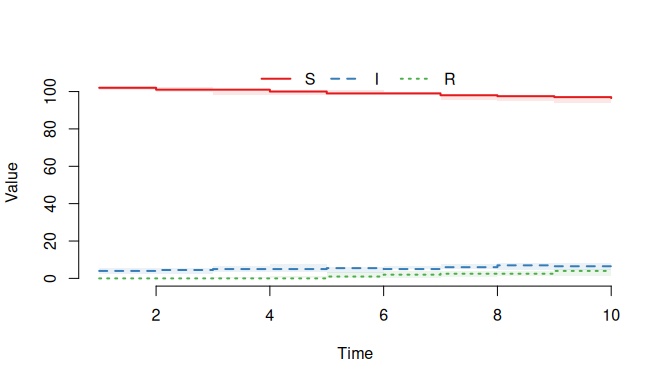

```r
plot(result)
```

Plot the median and the middle 95% quantile range of the number of susceptible, infected and recovered individuals.

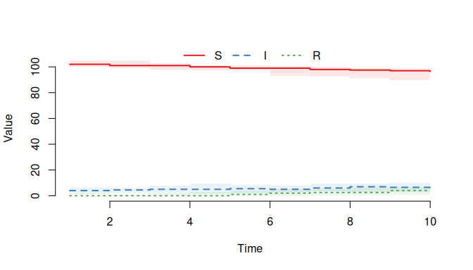

```r
plot(result, range = 0.95)
```

Plot the median and interquartile range of the number of infected individuals.

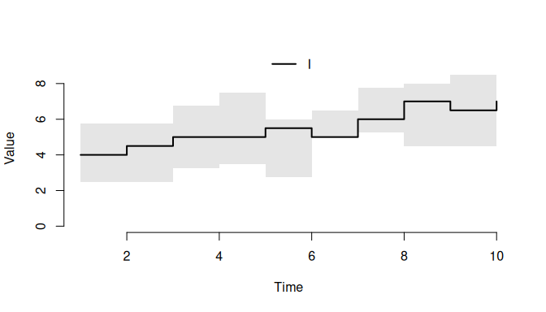

```r
plot(result, "I")
```

Use the formula notation instead to plot the median and interquartile range of the number of infected individuals.

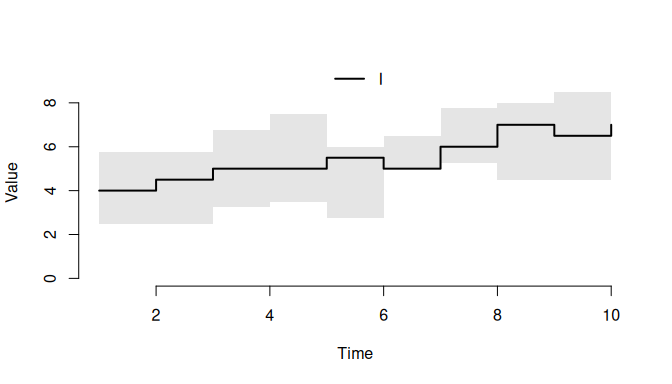

```r
plot(result, ~I)
```

Plot the number of susceptible, infected and recovered individuals in the first three nodes.

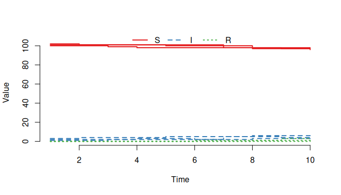

```r
plot(result, index = 1:3, range = FALSE)
```

Use plot type line instead.

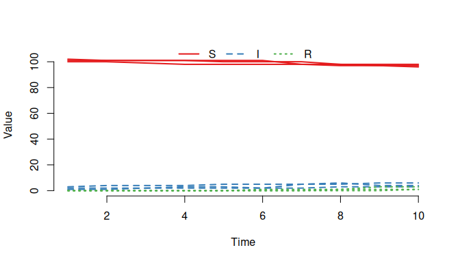

```r
plot(result, index = 1:3, range = FALSE, type = "l")
```

Plot the number of infected individuals in the first node.

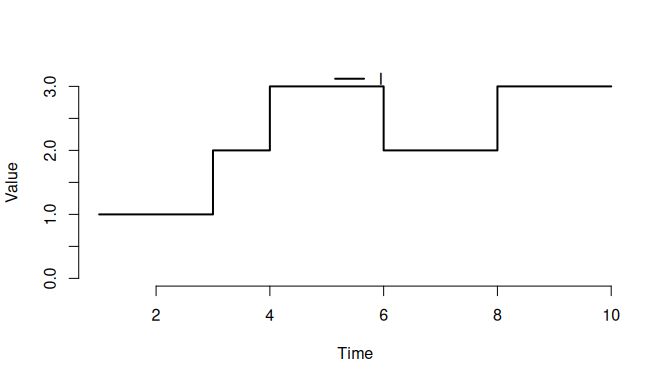

```r
plot(result, "I", index = 1, range = FALSE)
```

Plot the proportion of infected individuals (cases) in the population.

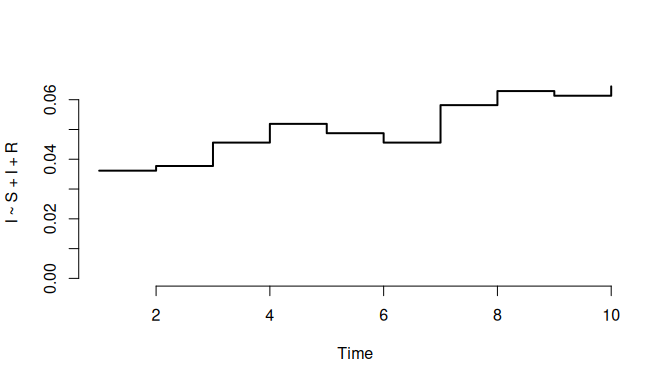

```r
plot(result, I ~ S + I + R)
```

Plot the proportion of nodes with infected individuals.

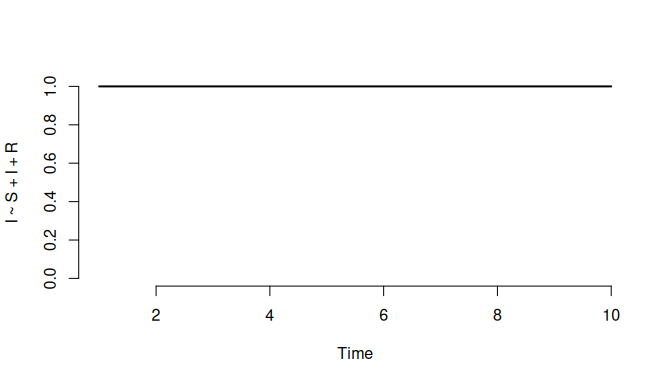

```r
plot(result, I ~ S + I + R, level = 2)
```

Plot the median and interquartile range of the proportion of infected individuals in each node

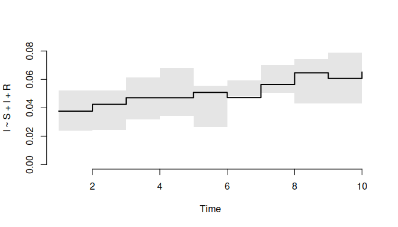

```r
plot(result, I ~ S + I + R, level = 3)
```

Plot the proportion of infected individuals in the first three nodes.

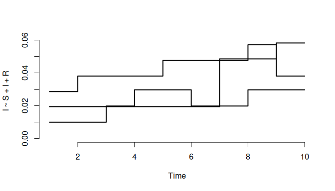

```r
plot(result, I ~ S + I + R, level = 3, index = 1:3, range = FALSE)
```

Please run a couple of `plot(run(model))` to view the stochasticity between trajectories. To find help on the SimInf plot function for the model object run:

```r
help("plot,SimInf_model-method", package = "SimInf")
```